# Exploratory Data Analysis of Air Quality

Balázs Nyári

**Exercise 3**

- Produce a report in the form of an R Notebook
- The Notebook should include:
  - Code
  - Output generated
  - Formatted text to describe your working, including obesrvations about the dataset
- The report should include the following
  - General information about the dataset - examples of rows or data, details about variables and no. observations
  - Descriptive statistics - measures of central tendency and variation for relevant variables (the sapply function could be used)
  - Data cleaning - replace missing values with the mean for the variable (see) section 7 of Practical 2)
  - Data visualisation - scatter plots, histograms and boxplots
  - Correlations between relevant variables
  - Boxplots by month (you will need to convert the month variable from an integer variable to a categorical varaible - slide 53, week 3)
  - Density Plots by month (slide 48, week 3)

Examples of **rows**, details about **variables** and **number of observations**

**General Information about the dataset**

```r
df <- airquality
summary(df)
```

```
##      Ozone           Solar.R           Wind             Temp
##  Min.   :  1.00   Min.   :  7.0   Min.   : 1.700   Min.   :56.00
##  1st Qu.: 18.00   1st Qu.:115.8   1st Qu.: 7.400   1st Qu.:72.00
##  Median : 31.50   Median :205.0   Median : 9.700   Median :79.00
##  Mean   : 42.13   Mean   :185.9   Mean   : 9.958   Mean   :77.88
##  3rd Qu.: 63.25   3rd Qu.:258.8   3rd Qu.:11.500   3rd Qu.:85.00
##  Max.   :168.00   Max.   :334.0   Max.   :20.700   Max.   :97.00
##  NA's   :37       NA's   :7
##      Month            Day
##  Min.   :5.000   Min.   : 1.0
##  1st Qu.:6.000   1st Qu.: 8.0
##  Median :7.000   Median :16.0
##  Mean   :6.993   Mean   :15.8
##  3rd Qu.:8.000   3rd Qu.:23.0
##  Max.   :9.000   Max.   :31.0
##
```

**Examples of rows**

```r
head(df)
```

```
##   Ozone Solar.R Wind Temp Month Day
## 1    41     190  7.4   67     5   1
## 2    36     118  8.0   72     5   2
## 3    12     149 12.6   74     5   3
## 4    18     313 11.5   62     5   4
## 5    NA      NA 14.3   56     5   5
## 6    28      NA 14.9   66     5   6
```

**Details about variables and number of observations (153)**

```r
str(df)
```

```
## 'data.frame':    153 obs. of  6 variables:
##  $ Ozone  : int  41 36 12 18 NA 28 23 19 8 NA ...
##  $ Solar.R: int  190 118 149 313 NA NA 299 99 19 194 ...
##  $ Wind   : num  7.4 8 12.6 11.5 14.3 14.9 8.6 13.8 20.1 8.6 ...
##  $ Temp   : int  67 72 74 62 56 66 65 59 61 69 ...
##  $ Month  : int  5 5 5 5 5 5 5 5 5 5 ...
##  $ Day    : int  1 2 3 4 5 6 7 8 9 10 ...
```

**Descriptive Statistics**

- Measures of central tendency and variation for relevant variables
  - mean, median of the dataset essentially
- sapply function could be used

*Central Tendency* of **Wind Speeds** at LaGuardia Airport

- Display *Mean* and *Standard Deviation*

```r
# Mean
sapply(df[,-5:-6], na.rm=TRUE, mean)
```

```
##      Ozone    Solar.R       Wind       Temp
##  42.129310 185.931507   9.957516  77.882353
```

```r
# Standard Deviation
sapply(df[,-5:-6], na.rm=TRUE, sd)
```

```
##     Ozone   Solar.R      Wind      Temp
## 32.987885 90.058422  3.523001  9.465270
```

**Data cleaning** - replacing missing values with the mean for the variable

- This only applies to *Solar.R* field & *Ozone*

```r
sum(is.na(df))
```

```
## [1] 44
```

```r
colSums(is.na(df))
```

```
##   Ozone Solar.R    Wind    Temp   Month     Day
##      37       7       0       0       0       0
```

```r
df$Solar.R[is.na(df$Solar.R)] <- mean(df$Solar.R, na.rm = TRUE)
df$Ozone[is.na(df$Ozone)] <- mean(df$Ozone, na.rm = TRUE)
head(df)
```

```
##      Ozone  Solar.R Wind Temp Month Day
## 1 41.00000 190.0000  7.4   67     5   1
## 2 36.00000 118.0000  8.0   72     5   2
## 3 12.00000 149.0000 12.6   74     5   3
## 4 18.00000 313.0000 11.5   62     5   4
## 5 42.12931 185.9315 14.3   56     5   5
## 6 28.00000 185.9315 14.9   66     5   6
```

Display Mean and Standard Deviation after Replacing Missing Data

- (Note that the mean has not changed but the standard deviation is reduced)

```r
# Mean - After changes
sapply(df[,-5:-6], na.rm=TRUE, mean)
```

```
##      Ozone    Solar.R       Wind       Temp
##  42.129310 185.931507   9.957516  77.882353
```

```r
# Standard Deviation - After changes
sapply(df[,-5:-6], na.rm=TRUE, sd)
```

```
##     Ozone   Solar.R      Wind      Temp
## 28.693372 87.960267  3.523001  9.465270
```

**Data visualisation**

- scatter plots, histograms and boxplots

**Scatter Plots**

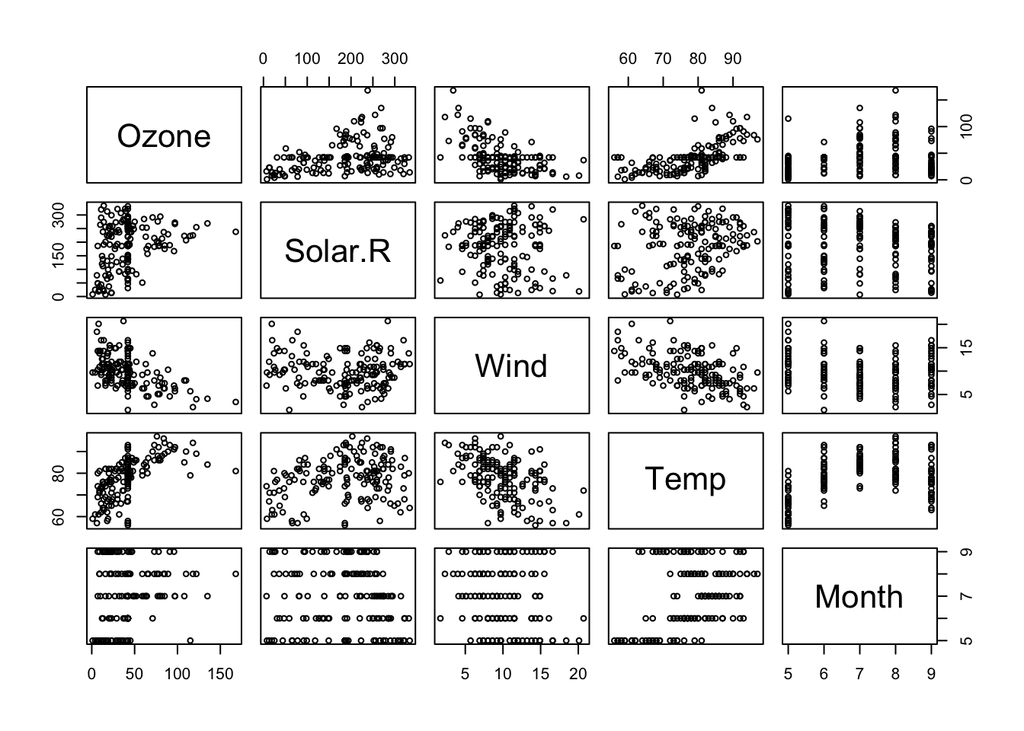

```r
# Pretty broken function
pairs(df[,-6], cex=0.7)
```

**Box Plots**

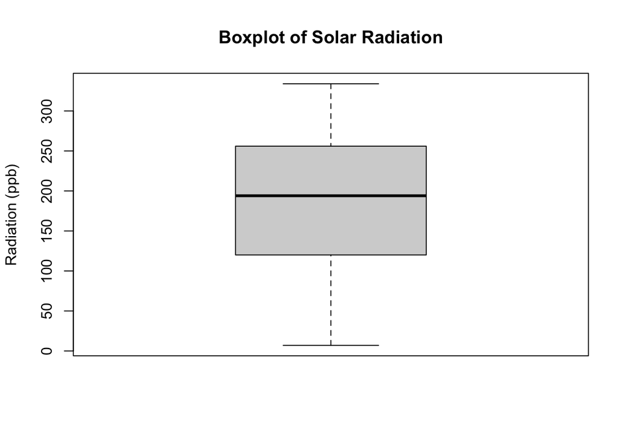

```r
boxplot(df$Solar.R, main="Boxplot of Solar Radiation", ylab="Radiation (ppb)")
```

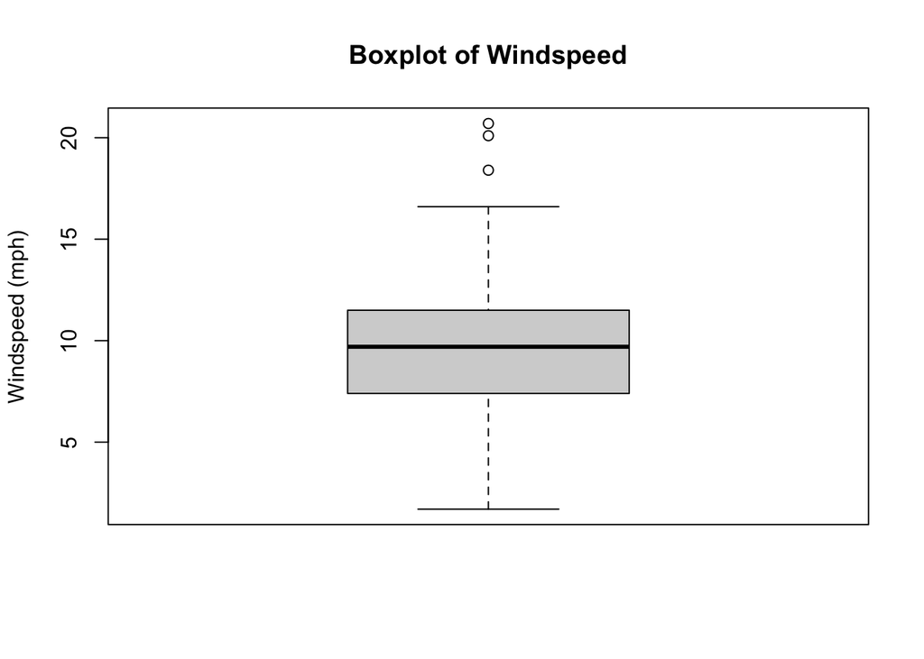

```r
boxplot(df$Wind, main="Boxplot of Windspeed", ylab="Windspeed (mph)")
```

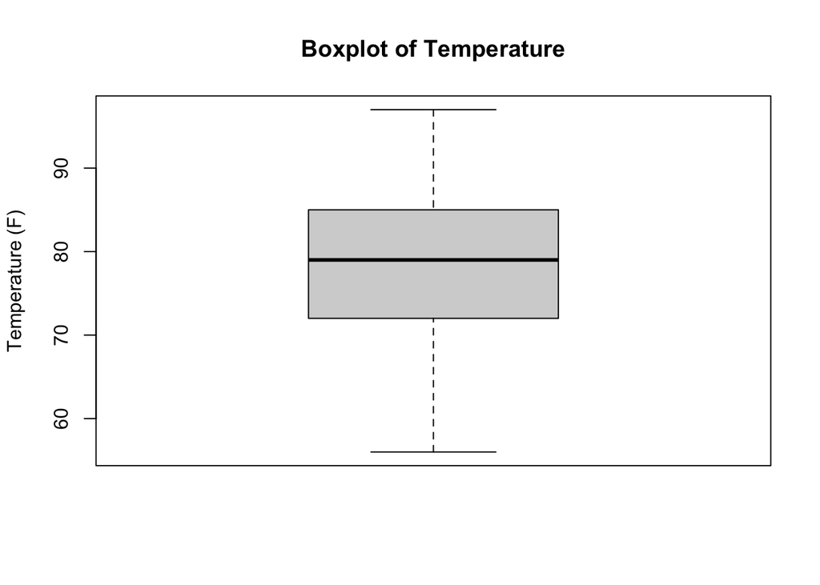

```r
boxplot(df$Temp, main="Boxplot of Temperature", ylab="Temperature (F)")
```

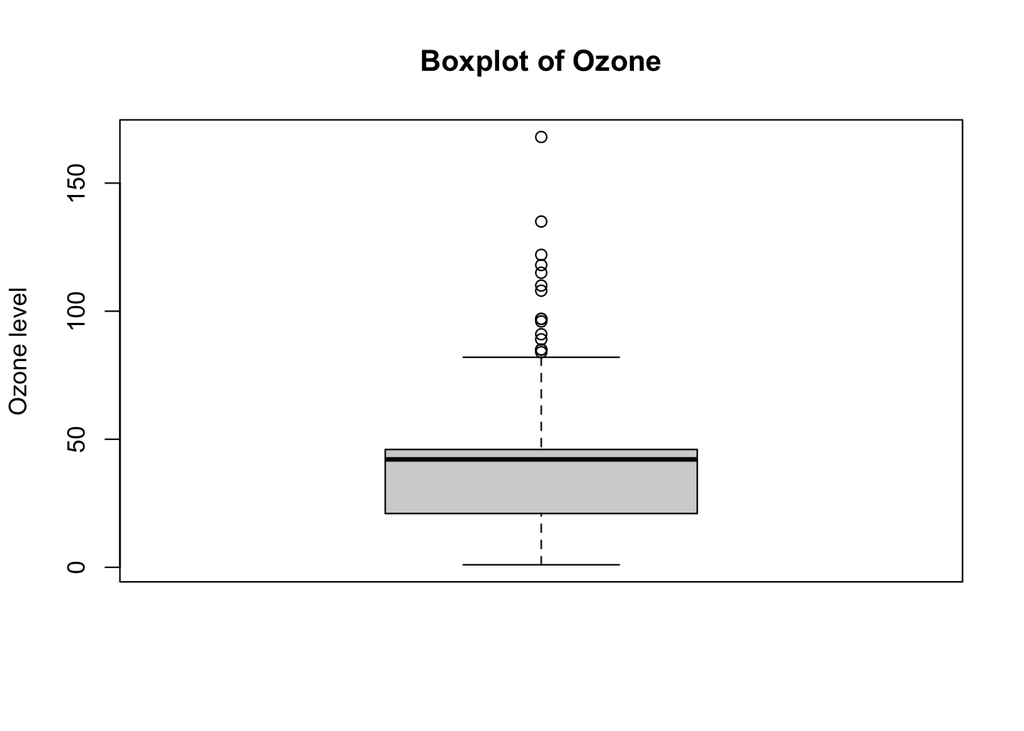

```r
boxplot(df$Ozone, main="Boxplot of Ozone", ylab="Ozone level")
```

**Histogram**

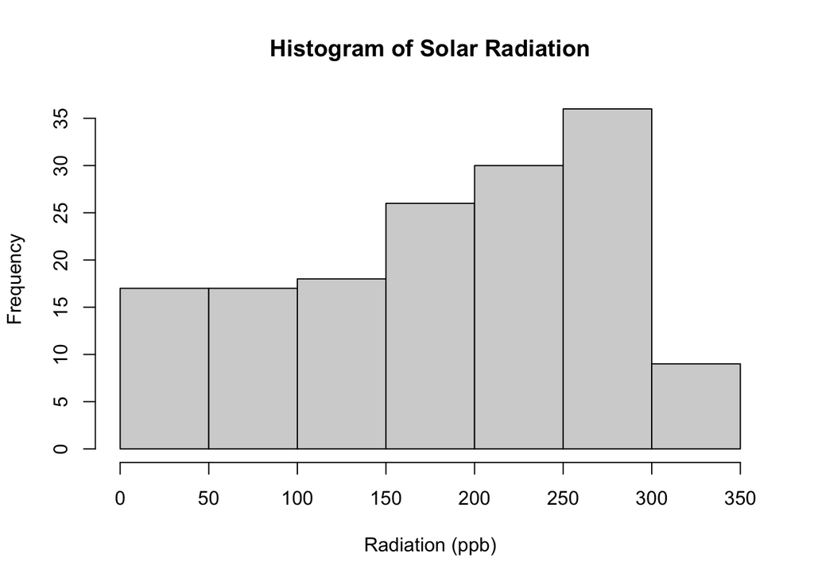

```r
hist(df$Solar.R, main = "Histogram of Solar Radiation", xlab ="Radiation (ppb)")
```

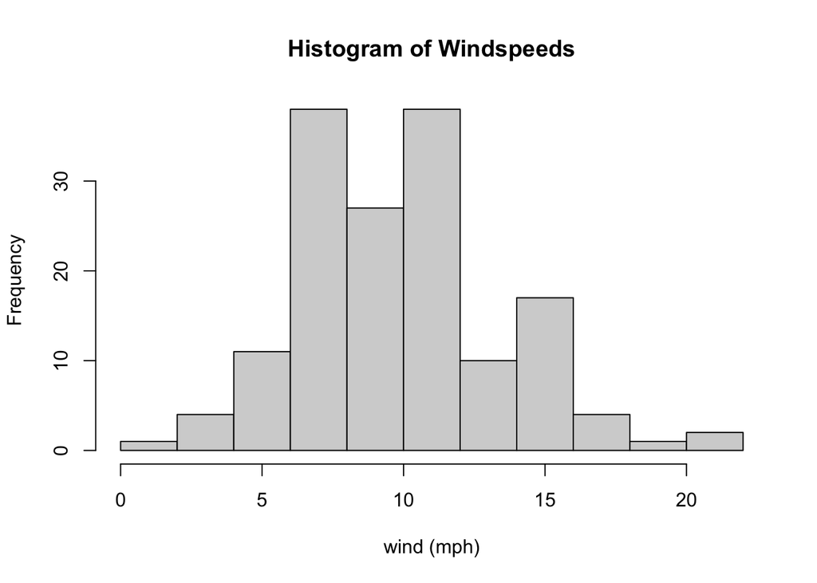

```r
hist(df$Wind, main = "Histogram of Windspeeds", xlab ="wind (mph)")
```

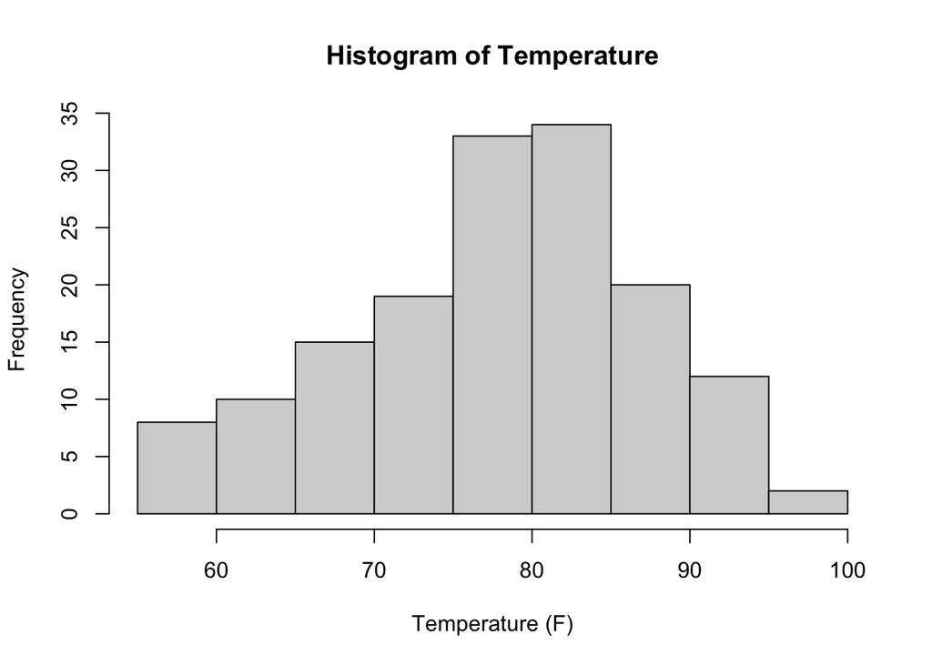

```r
hist(df$Temp, main = "Histogram of Temperature", xlab ="Temperature (F)")
```

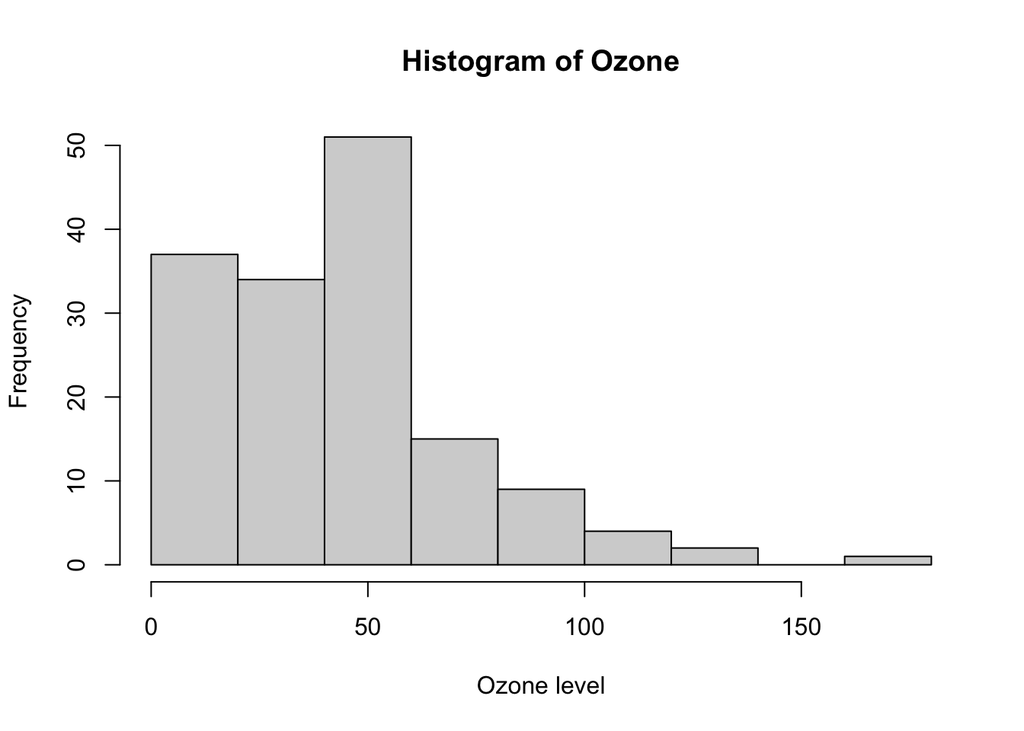

```r
hist(df$Ozone, main = "Histogram of Ozone", xlab ="Ozone level")
```

**Correlation Plot**

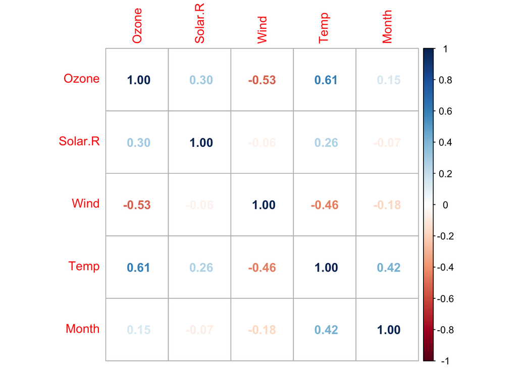

```r
library(corrplot)
M <- cor(df[,-6])
corrplot(M, method='number')
```

**Boxplots by month**

- Convert *Month* variable from an integer variable to a categorical variable

```r
df$Month = factor(df$Month)
str(df) # Factor w/5 levels created
```

```
## 'data.frame':    153 obs. of  6 variables:
##  $ Ozone  : num  41 36 12 18 42.1 ...
##  $ Solar.R: num  190 118 149 313 186 ...
##  $ Wind   : num  7.4 8 12.6 11.5 14.3 14.9 8.6 13.8 20.1 8.6 ...
##  $ Temp   : int  67 72 74 62 56 66 65 59 61 69 ...
##  $ Month  : Factor w/ 5 levels "5","6","7","8",..: 1 1 1 1 1 1 1 1 1 1 ...
##  $ Day    : int  1 2 3 4 5 6 7 8 9 10 ...
```

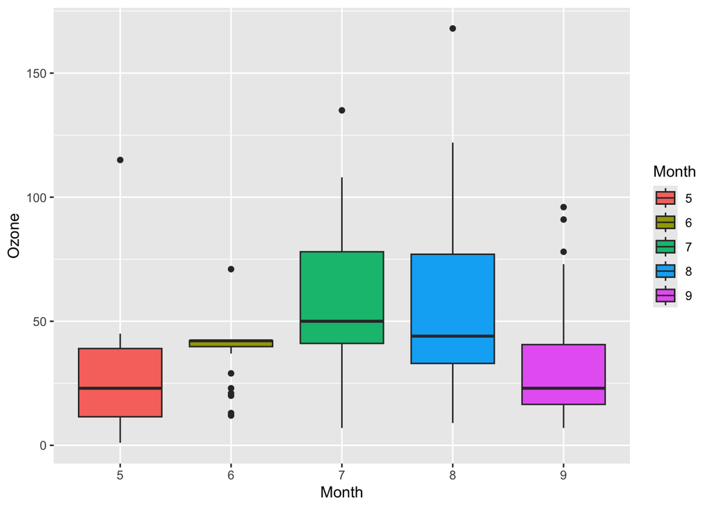

```r
# boxplot(df$Month) - WRONG
# ******* USE GGPLOT! *********
library(ggplot2)
ggplot(df, aes(x=Month, y=Ozone)) + geom_boxplot(aes(fill=Month))
```

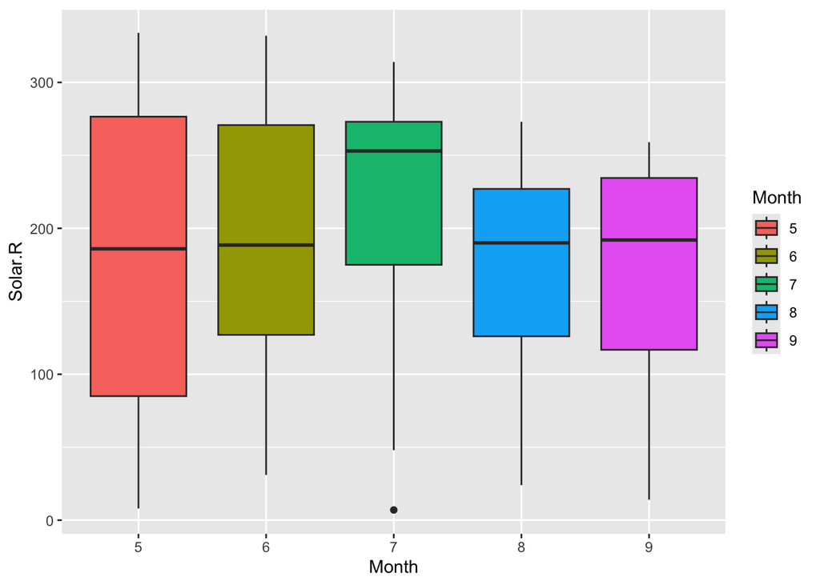

```r
ggplot(df, aes(x=Month, y=Solar.R)) + geom_boxplot(aes(fill=Month))
```

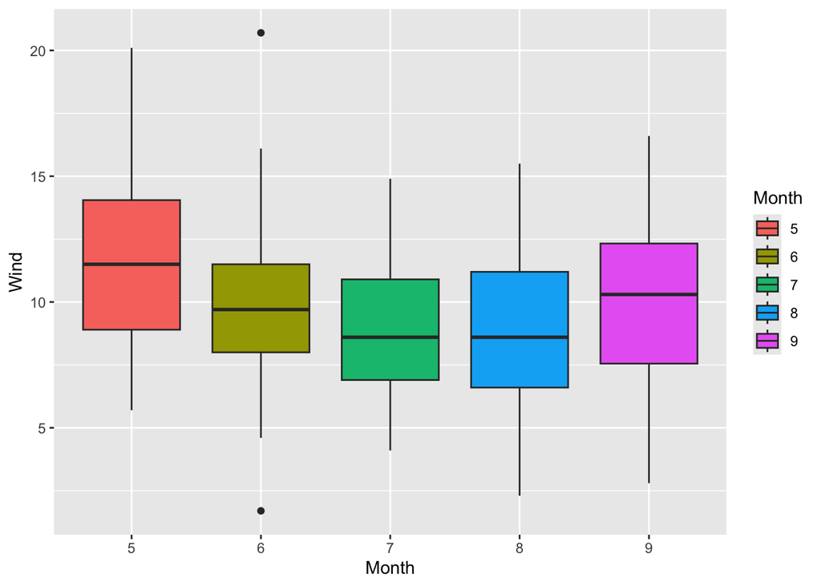

```r
ggplot(df, aes(x=Month, y=Wind)) + geom_boxplot(aes(fill=Month))
```

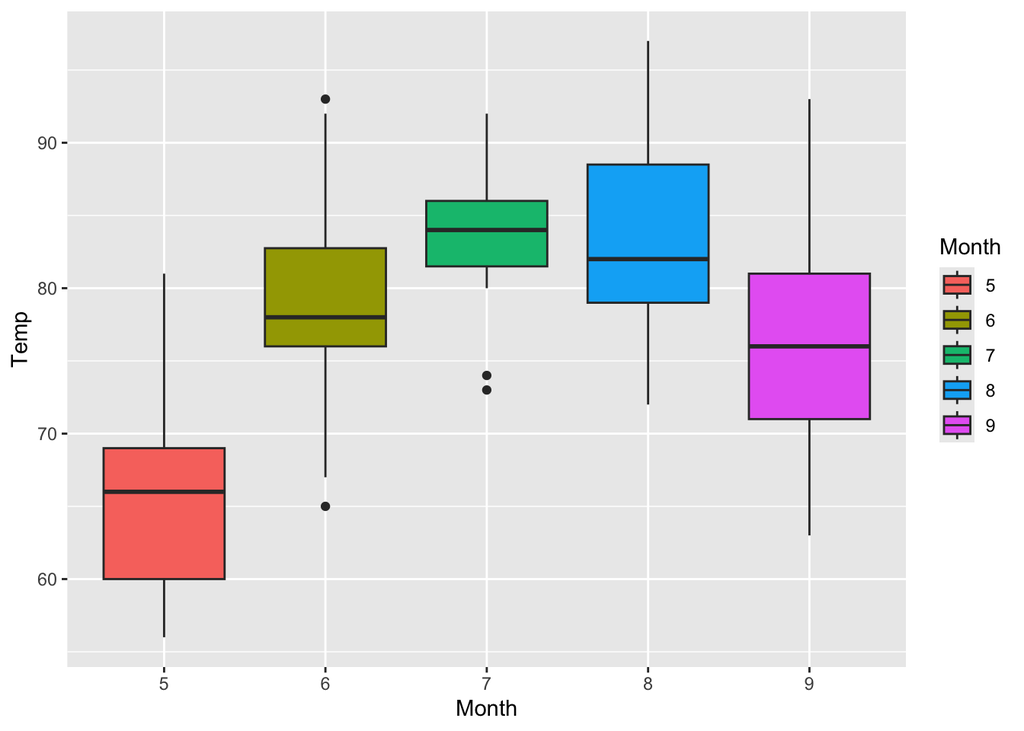

```r
ggplot(df, aes(x=Month, y=Temp)) + geom_boxplot(aes(fill=Month))
```

**Density plots** by *Month*

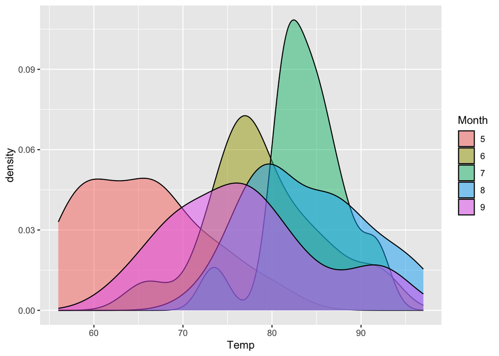

```r
library(ggplot2)
# Correct!!!
ggplot(df,aes(x=Temp)) +
  geom_density(aes(fill = Month), alpha = 0.5)
```

**More Learning Required**

- Using *Ggplot* to plot boxplots!
- using *pairs* to plot a fuck ton of scatter graphs at once
- **DATA CLEANSING** - df$Ozone[is.na(df$Ozone)] <- mean(df$Ozone, na.rm = TRUE)
- sapply function - sapply(df[,-5:-6], na.rm=TRUE, mean)